# Spatial Cluster Randomized Trials - Sampling Design with Heterogeneous Outcome Incidence

Authors

Affiliations

Andrew Walther

The University of North Carolina at Chapel Hill, Department of Biostatistics

Tonya Van Deinse

The University of North Carolina at Chapel Hill, School of Social Work

Feng-Chang Lin

The University of North Carolina at Chapel Hill, Department of Biostatistics

Published

March 24, 2026

**Keywords:** spatial autoregressive, treatment assignment, cluster randomized trials, spillover effects, incidence-guided design, simulation study

## Abstract

**Background**: Investigators designing cluster randomized trials (CRTs) frequently encounter spatial dependence and spillover effects. While prior work has explored spatial stratification under uniform assumptions, real-world trials often feature strong, spatially heterogeneous baseline incidence. Understanding how to leverage known prior incidence to optimize spatial treatment assignment remains a critical knowledge gap.

**Methods & Simulation**: A Monte Carlo simulation on a $10 \times 10$ spatial lattice evaluated eight treatment assignment strategies, contrasting strictly spatial methods (checkerboard stratification, $2\times 2$ random blocking, treatment isolation buffer clusters, and saturation quadrants) with covariate-constrained methods utilizing baseline incidence (median incidence grouping, treatment balanced incidence quartiles, balanced halves, and incidence-guided saturation quadrants). A Spatial Durbin Model (SDM) generated outcomes across varying levels of spatial dependence, spillover magnitude, and incidence structures (iid Uniform, spatially correlated, and Poisson count-based rates). Intervention effect estimation was evaluated using spatial Maximum Likelihood Estimation (MLE) to appropriately model spatial auto-regression, across 2,560 total parameter scenarios.

# 1 Introduction

## 1.1 Background & Motivation

Randomized controlled trials (RCTs) represent the preeminent methodological framework for establishing causal inference when evaluating the efficacy and safety of novel interventions (Pocock 1983; Smith, Morrow, and Ross 2015). By randomly allocating subjects to intervention or control arms, investigators ensure that measured and unmeasured confounding variables are theoretically balanced in expectation, thereby permitting an unbiased estimation of the average treatment effect. However, in numerous public health and social science contexts, randomizing at the individual level is logistically infeasible or scientifically inappropriate due to the community-level delivery of the intervention. For instance, interventions such as mass media health education campaigns or community-wide vector control mechanisms inherently apply to collective groups rather than discrete individuals. In such scenarios, the cluster randomized trial (CRT) emerges as a rigorous alternative, allocating intact social units or geographically defined regions (e.g., schools, clinics, counties) to study arms (Hayes and Moulton 2017; Donner and Klar 2000).

Although CRTs successfully mitigate logistical barriers and attenuate within-cluster treatment contamination, geographically clustered trials introduce complex spatial dynamics that challenge the fundamental statistical assumption of unit independence. Two primary and interrelated spatial phenomena uniquely compromise the internal validity of spatial CRTs: spillover effects and spatial dependence (Hayes and Moulton 2017; Hudgens and Halloran 2008). Spillover, or interference, occurs when the application of an intervention in one cluster alters the potential outcomes of subjects residing in neighboring unassigned clusters. This transboundary phenomenon is extensively documented in community-based research, particularly within infectious disease interventions such as the deployment of permethrin-impregnated bed nets (Binka, Indome, and Smith 1998; Gimnig et al. 2003; Hawley et al. 2003) and school-based deworming programs (Miguel and Kremer 2004). Under these conditions, control clusters situated near intervention clusters may receive a protective positive externality, thereby artificially enhancing their observed outcomes. Failing to account for this interference violates the Stable Unit Treatment Value Assumption (SUTVA), frequently precipitating a severe underestimation of the true direct effect of the intervention (Anaya‐Izquierdo and Alexander 2021).

Compounding this methodological challenge is spatial dependence, conceptualized by Tobler’s First Law of Geography, which postulates that proximally located entities exhibit greater similarity than distant ones (Tobler 1970). In a spatial CRT, adjacent clusters often share unmeasured environmental exposures or socioeconomic demographics, causing their outcomes to be correlated independent of treatment assignment (Cressie 1993). Ignoring this underlying spatial structure inherently assumes a greater effective sample size than actually exists, which artificially deflates standard errors, inflates the Type I error rate, and jeopardizes valid statistical inference (Campbell and Walters 2014; Ntani et al. 2021).

Historically, the biostatistical and epidemiological literature has primarily confronted these challenges through retrospective analytical adjustments rather than via proactive trial design modifications. A systematic review by Jarvis et al. (2017) indicated that spatial location is frequently treated as an afterthought in CRT design. When researchers do account for spatial phenomena, they typically rely upon spatial variable approaches (such as incorporating distance-based covariates) (Hawley et al. 2003; Lenhart et al. 2008; Chao et al. 2015) or spatial modeling techniques that integrate geographic structure into the covariance matrix (Alexander et al. 2003; Silcocks and Kendrick 2010). While robust, relying solely on statistical correction post-data collection may result in a substantive loss of statistical power and remains highly vulnerable to model misspecification. Consequently, recent methodological literature has begun to advocate for addressing spatial interference proactively at the design stage, demonstrating that strictly spatial sampling strategies like block stratified sampling can minimize estimation variance compared to simple random sampling by physically isolating treatment clusters.

Nevertheless, a critical gap remains regarding the performance of these design strategies under real-world conditions. The current spatial design literature predominantly operates under the assumption of a homogeneous spatial landscape. Empirically, this assumption rarely holds; geographic regions exhibit pronounced, spatially heterogeneous baseline incidence of primary outcomes prior to the introduction of any intervention. Conditions such as Sudden Unexpected Death (SUD) or localized infectious disease outbreaks frequently manifest in distinct geographic hotspots driven by localized socioeconomic determinants (Mirzaei et al. 2019). When a spatially structured incidence profile exists, relying on strictly geometric randomization risks inducing severe systematic confounding. An intervention assignment may inadvertently align perfectly with an underlying disease hotspot, inducing structural multicollinearity. This confounds the spatial lag of the treatment with the endogenous spatial lag of the baseline risk, rendering it mathematically intractable for spatial autoregressive models to disentangle the direct intervention effect from the clustered pre-existing burden. Consequently, there is a profound lack of evidence-based guidance detailing how investigators might actively leverage known prior distributions of outcome incidence to optimize spatial treatment allocation.

## 1.2 Aims & Contributions

The present study addresses this critical methodological gap by shifting the analytical focus from retrospective spatial adjustments toward the rigorous evaluation of incidence-guided treatment sampling designs. By integrating pre-intervention epidemiological data directly into the randomization protocol, researchers can theoretically orthogonalize the treatment assignment from underlying spatial risks, thereby preserving the validity of subsequent causal inferences. The primary objective is to determine the extent to which the incorporation of historical incidence data during the treatment assignment phase minimizes estimation error for the direct intervention effect, particularly in the presence of unobserved spillover and spatial dependence. To achieve this objective, an extensive Monte Carlo simulation study is conducted on a regular spatial lattice, systematically comparing the estimation efficiency of eight distinct treatment assignment strategies. This analysis contrasts strictly spatial sampling methods (checkerboard stratification, 2x2 random blocking, isolation buffer, and saturation quadrants) against covariate-constrained methods that directly utilize baseline incidence data (median incidence grouping, balanced incidence quartiles, balanced halves, and incidence-guided saturation quadrants).

# 2 Theoretical Methods

## 2.1 Study Region and Spatial Structure

To formalize the spatial relationships inherent in a cluster randomized trial (CRT), the theoretical study region is defined as a regular square lattice grid. Let the spatial domain be denoted as $\mathcal{G} = \{s_1, s_2, \dots, s_N\}$, where each spatial cluster $s_i$ is located at discrete integer coordinates $(x_i, y_i)$. The total number of uniformly sized clusters within the geographic network is $N$. Utilizing a regular lattice structure isolates the methodological evaluation of the sampling designs from the confounding effects of irregular polygon geometries and heterogeneous cluster populations, providing a standardized baseline to systematically compare trial designs (Cressie 1993).

The spatial relationships between clusters are parameterized using strict contiguity-based definitions, which dictate the pathways through which intervention effects and spatial dependence propagate. Two primary contiguity structures are formalized for this framework:

1. **Rook Contiguity:** Clusters are considered adjacent neighbors strictly if they share a direct horizontal or vertical edge. The neighborhood set for a given cluster $s_i$ under Rook contiguity is defined as:
   $$\mathcal{N}_R(s_i) = \left\{ s_j \in \mathcal{G} : |x_i - x_j| + |y_i - y_j| = 1 \right\}$$
2. **Queen Contiguity:** Clusters are considered neighbors if they share either a direct edge or a single vertex, inherently including diagonal adjacencies. The corresponding neighborhood set is defined as:
   $$\mathcal{N}_Q(s_i) = \left\{ s_j \in \mathcal{G} : \max(|x_i - x_j|, |y_i - y_j|) = 1 \right\}$$

To incorporate these neighborhood structures into the spatial econometric modeling, an $N \times N$ spatial weight matrix, $\mathbf{W}$, is constructed (LeSage and Pace 2009). Let $\mathbf{A}$ denote an $N \times N$ binary adjacency matrix where the element $A_{ij} = 1$ if $s_j \in \mathcal{N}(s_i)$, and $A_{ij} = 0$ otherwise. By convention, $A_{ii} = 0$ for all $i$. Clusters located on the boundaries of the spatial grid naturally possess fewer neighbors (edge effects). To facilitate the interpretation of spatial lags as localized neighborhood averages, the weight matrix $\mathbf{W}$ is row-standardized. This row-standardization inherently compensates for these edge effects by distributing the total weight equally among the available neighbors. The elements of the row-standardized spatial weight matrix are defined as:

$$W_{ij} = \frac{A_{ij}}{\sum_{k=1}^N A_{ik}} \quad \text{for } i \neq j, \text{ and } W_{ii} = 0$$

## 2.2 Data Generating Process and the Spatial Durbin Model

In community-based public health trials, the observed outcome within a specific geographic cluster is rarely independent of its surrounding spatial context. To capture both the endogenous spatial dependence of the outcome variable and the exogenous spillover effects generated by the localized treatment, the data-generating process utilizes the Spatial Durbin Model (SDM) (LeSage and Pace 2009). The continuous outcome vector for the spatial grid, $\mathbf{Y} = (Y_1, \dots, Y_N)^\top$, is expressed in its reduced structural form as:

$$\mathbf{Y} = (\mathbf{I}_N - \rho \mathbf{W})^{-1} [\tau \mathbf{Z} + \gamma \cdot \text{Spill}(\mathbf{Z}) + \beta \mathbf{X} + \mathbf{\epsilon}]$$

In this structural equation, the parameters operate as follows:

- $\mathbf{I}_N$ is the $N \times N$ identity matrix.
- $(\mathbf{I}_N - \rho \mathbf{W})^{-1}$ acts as the global spatial multiplier, inducing global spatial dependence and ensuring that a localized intervention effect reverberates throughout the entire spatial network, decaying exponentially with topological distance.
- $\rho$ is the spatial autocorrelation coefficient. The condition $|\rho| < 1$ must be maintained to ensure the matrix is invertible and the spatial process remains stable.
- $\tau$ is the primary estimand of interest, representing the true direct effect of the intervention on the treated cluster.
- $\mathbf{Z}$ is an $N \times 1$ binary treatment assignment vector, where $Z_i = 1$ indicates that cluster $s_i$ received the active intervention.
- $\mathbf{X}$ is an $N \times 1$ continuous vector representing the pre-existing baseline outcome incidence within each cluster.
- $\beta$ is a scalar coefficient governing the direct linear effect of the baseline incidence $\mathbf{X}$ on the final observed outcome.
- $\mathbf{\epsilon}$ represents an $N \times 1$ vector of independent and identically distributed random error terms, where $\mathbf{\epsilon} \sim \mathcal{N}(\mathbf{0}, \sigma^2 \mathbf{I}_N)$.

The function $\text{Spill}(\mathbf{Z})$ calculates an $N \times 1$ vector representing the degree of indirect treatment exposure that each cluster receives from its immediate neighbors, weighted by the scalar spillover magnitude parameter, $\gamma$. The base spillover exposure for a given cluster $i$ is calculated as the proportion of its contiguous neighbors assigned to the intervention arm: $(\mathbf{W}\mathbf{Z})_i = \frac{1}{|\mathcal{N}(i)|} \sum_{j \in \mathcal{N}(i)} Z_j$.

This framework accommodates two mathematical mechanisms of spillover propagation:

1. **Bidirectional Spillover (Intervention & Control):** The indirect spillover effect impacts all clusters in the network regardless of their internal treatment assignment status. The exposure for cluster $i$ is defined as $\text{Spill}_i^{(\text{both})} = (\mathbf{W}\mathbf{Z})_i$.
2. **Control-Only Spillover:** The spillover effect functions exclusively as an externality for clusters that did not directly receive the intervention. The exposure is defined using a Hadamard product: $\text{Spill}_i^{(\text{ctrl})} = (\mathbf{W}\mathbf{Z})_i \cdot (1 - Z_i)$.

## 2.3 Spatially Heterogeneous Incidence Generation

The baseline incidence vector $\mathbf{X}$ models the historical, pre-intervention outcome rates distributed across the geographic clusters. To rigorously evaluate the vulnerability of spatial sampling designs to underlying data structures, $\mathbf{X}$ is generated via three distinct modes. The final incidence metric $X_i$ is computationally mapped to a strictly continuous scale bounded within $[0, 1]$.

**Mode 1: Independent and Identically Distributed (iid) Uniform Incidence.** As a methodological baseline, incidence is generated with no underlying spatial structure:
$$X_i \sim \text{Uniform}(0, 1) \quad \text{for } i = 1, \dots, N$$

**Mode 2: Spatially Correlated Incidence (SAR Filter).** To reflect scenarios where underlying outcomes naturally cluster geographically, incidence is generated utilizing a Simultaneous Autoregressive (SAR) filter (LeSage and Pace 2009):
$$\mathbf{X}^* = (\mathbf{I}_N - \rho_X \mathbf{W})^{-1} \mathbf{u}, \quad \text{where } \mathbf{u} \sim \mathcal{N}(\mathbf{0}, \mathbf{I}_N)$$

Here, $\rho_X \in [0, 1)$ controls the degree of spatial autocorrelation in baseline incidence. A probability integral transform is applied using the standard normal CDF, $\Phi(\cdot)$, yielding the final bounded incidence: $X_i = \Phi(X_i^*)$.

**Mode 3: Poisson Count-Based Incidence.** Motivated by empirical disease incidence distributions—specifically Sudden Unexpected Death (SUD) demographic data (Mirzaei et al. 2019; Gan et al. 2019)—this mode generates discrete event counts based on localized population densities and spatially correlated underlying relative risks. First, spatially correlated log-rates are generated:
$$\log \mathbf{\lambda}^* = \mu_0 \mathbf{1} + (\mathbf{I}_N - \rho_X \mathbf{W})^{-1} \mathbf{u}, \quad \text{where } \mathbf{u} \sim \mathcal{N}(\mathbf{0}, \mathbf{I}_N)$$

Expected case counts are drawn from a Poisson distribution scaled by cluster population $P_i$:
$$C_i \sim \text{Poisson}(\lambda_i^* P_i)$$

Observed rates $R_i = C_i / P_i$ are rank-normalized to preserve ordinal spatial clustering while mapping to $[0, 1]$:
$$X_i = \frac{\text{rank}(R_i) - 0.5}{N}$$

## 2.4 Treatment Assignment Designs

The explicit determination of the binary treatment vector $\mathbf{Z}$ dictates how the direct intervention is deployed across the targeted region. This methodology contrasts strictly spatial randomization methods against covariate-constrained assignment algorithms that actively utilize the observed incidence vector $\mathbf{X}$. Each sampling design targets a globally balanced allocation where approximately half of the clusters receive the intervention ($\sum_{i=1}^N Z_i \approx N/2$).

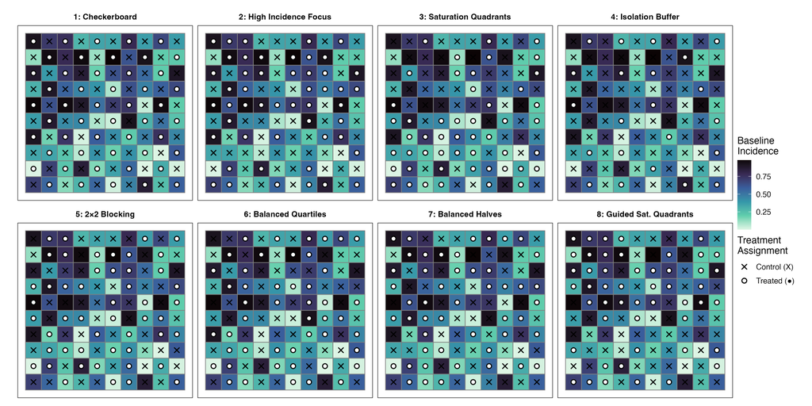

## 2.5 Estimation via Maximum Likelihood

In the presence of endogenous spatial dependence ($\rho \neq 0$) and exogenous spillover ($\gamma \neq 0$), estimators such as the Difference-in-Means fundamentally violate the Stable Unit Treatment Value Assumption (SUTVA). Furthermore, Ordinary Least Squares (OLS) regression fails as an unbiased estimator in this context due to continuous spatial feedback loops. Because the unobserved spatial structure correlates simultaneously with both the treatment assignment mechanics and the final outcome, the expected value of the error term conditional on the regressors is non-zero ($E[\mathbf{\epsilon} \mid \mathbf{Z}, \mathbf{W}] \neq 0$). Consequently, OLS models suffer from simultaneity bias, yielding systematically biased point estimates and artificially deflated standard errors.

To achieve statistically consistent estimation of the direct intervention effect $\tau$, a spatial autoregressive regression framework must be utilized (Bivand and Piras 2015). The corresponding empirical estimation model takes the matrix form:

$$\mathbf{Y} = \rho \mathbf{W} \mathbf{Y} + \mathbf{X}_{\text{design}}\mathbf{\beta}_{\text{design}} + \mathbf{\epsilon}$$

where the composite design matrix is $\mathbf{X}_{\text{design}} = [\mathbf{Z} \quad \text{Spill}(\mathbf{Z}) \quad \mathbf{X}]$ and the corresponding coefficient vector is $\mathbf{\beta}_{\text{design}} = (\tau, \gamma, \beta)^\top$.

Because the response variable $\mathbf{Y}$ appears on both sides of the structural equation, the parameters must be estimated simultaneously via concentrated Maximum Likelihood Estimation (MLE). This approach optimizes a log-likelihood function that explicitly incorporates the Jacobian determinant of the spatial transformation, $\ln|\mathbf{I}_N - \rho \mathbf{W}|$. This term evaluates the likelihood space and partitions the variance by concurrently estimating the spatial autocorrelation parameter alongside the direct and indirect treatment coefficients.

# 3 Simulation Study and Results

To empirically evaluate the performance of the proposed spatial and covariate-constrained sampling designs, an extensive Monte Carlo simulation study was conducted. The simulation assesses the efficiency and inferential validity of estimating the direct intervention effect ($\tau$) under varying degrees of spatial dependence, spillover magnitude, and structurally diverse baseline incidence distributions.

## 3.1 Simulation Algorithm and Parameter Space

The simulation was executed on a fixed $10 \times 10$ regular spatial lattice, yielding a total of $N = 100$ clusters. The true intervention effect ($\tau$), the baseline covariate coefficient ($\beta$), and the error variance ($\sigma^2$) were held constant at $1.0$ across all scenarios to establish a standardized baseline for comparison.

The parameter space was designed to capture a comprehensive range of spatial trial conditions. We systematically varied the following parameters:

- **Spatial Dependence ($\rho$):** $\{0.00, 0.01, 0.20, 0.50\}$
- **Spillover Magnitude ($\gamma$):** $\{0.50, 0.60, 0.70, 0.80\}$
- **Spillover Target Mechanism:** Bidirectional vs. Control-Only
- **Contiguity Definition:** Rook vs. Queen
- **Incidence Generation Modes:** iid Uniform, SAR Filter ($\rho_X \in \{0.20, 0.50\}$), Poisson Count-Based ($\rho_X \in \{0.20, 0.50\}$)
- **Treatment Assignment Designs:** All 8 designs described in Section 2

This yielded 5 incidence configurations $\times$ 2 neighbor types $\times$ 4 $\rho$ values $\times$ 4 $\gamma$ values $\times$ 2 spillover types $\times$ 8 designs = **2,560 total scenarios**.

To ensure rigorous evaluation while maintaining computational feasibility under spatial Maximum Likelihood Estimation (MLE), a nested resampling structure was employed:

1. **Spatial Initialization:** Establish the geographic grid and compute the row-standardized spatial weight matrix $\mathbf{W}$.
2. **Incidence Generation:** Draw the baseline incidence vector $\mathbf{X}$ according to the specified generation mode (generated once per incidence configuration and held fixed across all spatial parameter combinations).
3. **Design Resampling ($R_d = 25$):** For each of the eight evaluated sampling designs, generate 25 distinct binary treatment assignment vectors ($\mathbf{Z}$).
4. **Outcome Resampling ($R_o = 10$):** For each treatment assignment vector, simulate 10 unique error realizations ($\mathbf{\epsilon}$) to produce distinct outcome vectors ($\mathbf{Y}$) via the Spatial Durbin Model (SDM).
5. **Estimation:** Fit the spatial autoregressive MLE model to each generated dataset to estimate $\hat{\tau}$ and its standard error.

This nested structure yielded $R_{\text{total}} = 250$ independent model evaluations per scenario.

## 3.2 Evaluation Metrics

For each simulated trial iteration $r \in \{1, \dots, R_{\text{total}}\}$, the direct intervention effect was estimated via spatial MLE, producing the estimate $\hat{\tau}_r$ and its corresponding standard error $\text{SE}(\hat{\tau}_r)$. The comparative efficacy of the eight sampling designs was quantified using four primary performance metrics:

1. **Bias:** The empirical mean deviation of the estimates from the true intervention effect ($\tau = 1.0$).
   $$\text{Bias} = \frac{1}{R_{\text{total}}} \sum_{r=1}^{R_{\text{total}}} (\hat{\tau}_r - \tau)$$
2. **Empirical Standard Deviation (SD):** The variability of the point estimates across iterations.
   $$\text{SD} = \sqrt{ \frac{1}{R_{\text{total}} - 1} \sum_{r=1}^{R_{\text{total}}} \left( \hat{\tau}_r - \bar{\hat{\tau}} \right)^2 }$$
3. **Mean Squared Error (MSE):** The primary metric of overall estimation efficiency.
   $$\text{MSE} = \text{Bias}^2 + \text{SD}^2 = \frac{1}{R_{\text{total}}} \sum_{r=1}^{R_{\text{total}}} (\hat{\tau}_r - \tau)^2$$
4. **Coverage Probability (95% CI):** The proportion of simulated trials where the true parameter $\tau$ fell within the estimated 95% Wald confidence interval.
   $$\text{Coverage} = \frac{1}{R_{\text{total}}} \sum_{r=1}^{R_{\text{total}}} \mathbf{1} \left\{ \hat{\tau}_r - 1.96 \cdot \text{SE}(\hat{\tau}_r) \leq \tau \leq \hat{\tau}_r + 1.96 \cdot \text{SE}(\hat{\tau}_r) \right\}$$

## 3.3 Results: Design Performance

### 3.3.1 Overall Efficiency and Robustness

### 3.3.2 Impact of Spillover Magnitude and Spatial Dependence

### 3.3.3 Inferential Coverage and Type I Error Control

# 4 Application

## 4.1 Background of Sudden Death (SUD) in North Carolina

## 4.2 Spatial Considerations

## 4.3 Recommendations for Treatment Assignment

# 5 Discussion

## 5.1 Relevance of Results

## 5.2 Limitations

## 5.3 Future Considerations

## Authors’ Contributions

A.W. wrote the manuscript text, developed the simulation framework, and prepared all figures and tables. T.V. provided advisement for the application section and domain expertise in the NC criminal justice context. F.C.L. provided statistical methodology guidance and reviewed the manuscript. All authors reviewed the manuscript.

## Declarations

### Ethics, Consent to Participate, and Consent to Publish

Not applicable.

### Competing Interests

The authors declare that they have no competing interests.

## References

Alexander, Neal D, Rana A Moyeed, Phil J Hyun, Zachary B Dimber, Moses J Bockarie, Julian Stander, Bryan T Grenfell, James W Kazura, and Michael P Alpers. 2003. “Spatial Variation of Anopheles-Transmitted Wuchereria Bancrofti and Plasmodium Falciparuminfection Densities in Papua New Guinea.” *Filaria Journal* 2 (1): 14. https://doi.org/10.1186/1475-2883-2-14.

Anaya‐Izquierdo, Karim, and Neal Alexander. 2021. “Spatial Regression and Spillover Effects in Cluster Randomized Trials with Count Outcomes.” *Biometrics* 77 (2): 490–505. https://doi.org/10.1111/biom.13316.

Binka, F. N., F. Indome, and T. Smith. 1998. “Impact of Spatial Distribution of Permethrin-Impregnated Bed Nets on Child Mortality in Rural Northern Ghana.” *The American Journal of Tropical Medicine and Hygiene* 59 (1): 80–85. https://doi.org/10.4269/ajtmh.1998.59.80.

Bivand, Roger, and Gianfranco Piras. 2015. “Comparing Implementations of Estimation Methods for Spatial Econometrics.” *Journal of Statistical Software* 63 (18). https://doi.org/10.18637/jss.v063.i18.

Campbell, Michael J., and Stephen John Walters. 2014. *How to Design, Analyse and Report Cluster Randomised Trials in Medicine and Health Related Research*. Chichester, West Sussex: John Wiley & Sons.

Chao, D. L., J. K. Park, F. Marks, R. L. Ochiai, I. M. Longini, and M. E. Halloran. 2015. “The Contribution of Neighbours to an Individual’s Risk of Typhoid Outcome.” *Epidemiology and Infection* 143 (16): 3520–27. https://doi.org/10.1017/S0950268815000692.

Cressie, Noel A. C. 1993. *Statistics for Spatial Data*. 1st ed. Wiley Series in Probability and Statistics. Wiley. https://doi.org/10.1002/9781119115151.

Donner, Allan, and Neil Klar. 2000. *Design and Analysis of Cluster Randomization Trials in Health Research*. 1. publ. London: Arnold.

Gan, Zoe Su Wen, Wansuk Choi, Feng-Chang Lin, Rebecca Tippett, Golsa Joodi, Irion Pursell, and Ross Joseph Simpson. 2019. “Factors Underlying Increased Incidence of Sudden Unexpected Death in Rural Counties in North Carolina.” *Journal of General Internal Medicine* 34 (6): 815–17. https://doi.org/10.1007/s11606-018-4771-5.

Gimnig, John E., Margarette S. Kolczak, Allen W. Hightower, John M. Vulule, Erik Schoute, Luna Kamau, Penelope A. Phillips-Howard, Feiko O. ter Kuile, Bernard L. Nahlen, and William A. Hawley. 2003. “Effect of Permethrin-Treated Bed Nets on the Spatial Distribution of Malaria Vectors in Western Kenya.” *The American Journal of Tropical Medicine and Hygiene* 68 (4 Suppl): 115–20.

Hawley, William A., Penelope A. Phillips-Howard, Feiko O. ter Kuile, Dianne J. Terlouw, John M. Vulule, Maurice Ombok, Bernard L. Nahlen, et al. 2003. “Community-Wide Effects of Permethrin-Treated Bed Nets on Child Mortality and Malaria Morbidity in Western Kenya.” *The American Journal of Tropical Medicine and Hygiene* 68 (4 Suppl): 121–27.

Hayes, Richard J., and Lawrence H. Moulton. 2017. *Cluster Randomised Trials, Second Edition*. Chapman; Hall/CRC. https://doi.org/10.4324/9781315370286.

Hudgens, Michael G, and M. Elizabeth Halloran. 2008. “Toward Causal Inference With Interference.” *Journal of the American Statistical Association* 103 (482): 832–42. https://doi.org/10.1198/016214508000000292.

Jarvis, Christopher, Gian Luca Di Tanna, Daniel Lewis, Neal Alexander, and W. John Edmunds. 2017. “Spatial Analysis of Cluster Randomised Trials: A Systematic Review of Analysis Methods.” *Emerging Themes in Epidemiology* 14 (1): 12. https://doi.org/10.1186/s12982-017-0066-2.

Lenhart, Audrey, Nicolas Orelus, Rachael Maskill, Neal Alexander, Thomas Streit, and P. J. McCall. 2008. “Insecticide‐treated Bednets to Control Dengue Vectors: Preliminary Evidence from a Controlled Trial in Haiti.” *Tropical Medicine & International Health* 13 (1): 56–67. https://doi.org/10.1111/j.1365-3156.2007.01966.x.

LeSage, James, and Robert Kelley Pace. 2009. *Introduction to Spatial Econometrics*. 0th ed. Chapman; Hall/CRC. https://doi.org/10.1201/9781420064254.

Miguel, Edward, and Michael Kremer. 2004. “Worms: Identifying Impacts on Education and Health in the Presence of Treatment Externalities.” *Econometrica* 72 (1): 159–217. https://doi.org/10.1111/j.1468-0262.2004.00481.x.

Mirzaei, Mojtaba, Golsa Joodi, Brittany Bogle, Sarah Chen, and Ross J. Simpson. 2019. “Years of Life and Productivity Loss Because of Adult Sudden Unexpected Death in the United States.” *Medical Care* 57 (7): 498–502. https://doi.org/10.1097/MLR.0000000000001129.

Ntani, Georgia, Hazel Inskip, Clive Osmond, and David Coggon. 2021. “Consequences of Ignoring Clustering in Linear Regression.” *BMC Medical Research Methodology* 21 (1): 139. https://doi.org/10.1186/s12874-021-01333-7.

Pocock, Stuart J. 1983. *Clinical Trials: A Practical Approach*. A Wiley Medical Publication. Chichester [West Sussex] ; New York: Wiley.

Silcocks, Paul, and Denise Kendrick. 2010. “Spatial Effects Should Be Allowed for in Primary Care and Other Community-Based Cluster RCTS.” *Trials* 11 (1): 55. https://doi.org/10.1186/1745-6215-11-55.

Smith, Peter G., Richard H. Morrow, and David A. Ross, eds. 2015. *Field Trials of Health Interventions: A Toolbox*. 3rd ed. Wellcome Trust–Funded Monographs and Book Chapters. Oxford (UK): OUP Oxford. http://www.ncbi.nlm.nih.gov/books/NBK305515/.

Tobler, W. R. 1970. “A Computer Movie Simulating Urban Growth in the Detroit Region.” *Economic Geography* 46 (June): 234. https://doi.org/10.2307/143141.